# Reproducible Research: Peer Assessment 1

```r
knitr::opts_chunk$set(fig.height=4, fig.path='figure/',
                      echo=TRUE, warning=FALSE, message=FALSE)
```

## Loading and preprocessing the data

Open and read the csv file, located in local working directory. Format date using strftime to preserve char class for aggregate function used later.

```r
unzip("activity.zip", "activity.csv")
df <- read.csv("activity.csv",stringsAsFactors = FALSE,header = TRUE)
df$date <- strftime(df$date,format = "%Y-%m-%d")
```

## What is mean total number of steps taken per day?

First create summary data frame of steps by day. See /figure folder for histogram.

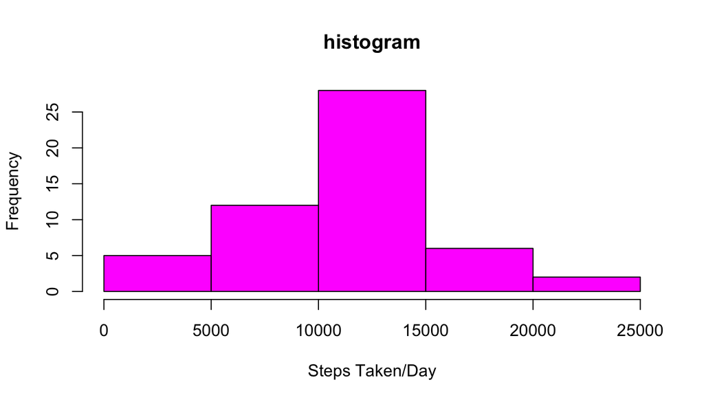

```r
step_sum <- aggregate(df$steps ~ date,df,FUN=sum)
names(step_sum) <- c("date","steps")
hist(step_sum$steps,main = "histogram", xlab="Steps Taken/Day",ylab="Frequency",col="magenta")
```

median and mean calculated using summary data frame

```r
cat("median of total daily steps is ",median(step_sum$steps))
```

```
## median of total daily steps is  10765
```

```r
cat("mean of total daily steps is ",mean(step_sum$steps))
```

```
## mean of total daily steps is  10766.19
```

## What is the average daily activity pattern?

Make a time series plot (i.e. type = “l”) of the 5-minute interval (x-axis) and the average number of steps taken, averaged across all days (y-axis). See /figure folder for plot.

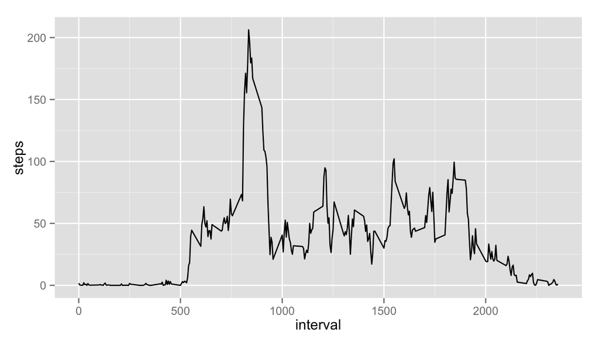

```r
library(ggplot2)
qplot(interval,steps,data = df, stat = 'summary',fun.y = 'mean',geom='line',na.rm=TRUE)
```

Calculate 5-minute interval, on average across all the days in the dataset, containing the maximum number of steps. First part creates a summary data frame by interval (across days). Second part returns the looked up value of interval associated with the maximum number of steps.

```r
tempdf <- aggregate(df$steps ~ interval,df,FUN=sum)
cat("interval with max steps is ",tempdf[tempdf[,2] == max(tempdf[,2]),1])
```

```
## interval with max steps is  835
```

## Imputing missing values

Calculate and report the total number of missing values in the dataset (i.e. the total number of rows with NAs)

```r
sum(is.na(df))
```

```
## [1] 2304
```

Devise a strategy for filling in all of the missing values in the dataset – I used mean of the 5-minute interval across all days. Create a new dataset that is equal to the original dataset but with the missing data filled in:

```r
df2 <- df ##copy dataframe to new dataframe
tempdf <- aggregate(df$steps ~ interval,df,FUN=mean) ##repurpose tempdf to aggregate by mean
for (i in 1:length(df2[,1])) {
  if (is.na(df2[i,1])) {df2[i,1] <- tempdf[tempdf[,1] == df2[i,3],2]} ##replace NAs with means
}
```

Make a histogram of the total number of steps taken each day (see /figure folder) and report the mean and median total number of steps taken per day.

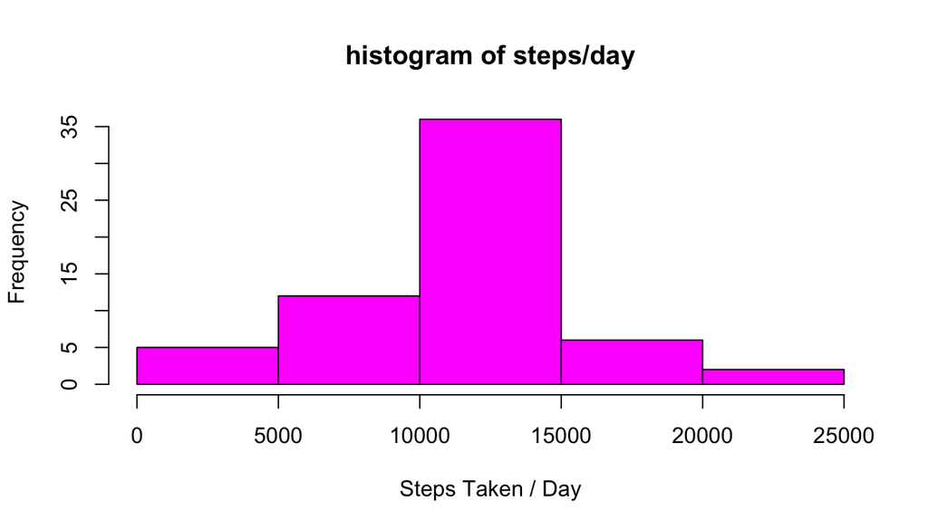

```r
step_sum2 <- aggregate(df2$steps ~ date,df,FUN=sum) ##summary df of total steps/day
names(step_sum2) <- c("date","steps")
hist(step_sum2$steps,main = "histogram of steps/day", xlab="Steps Taken / Day",ylab="Frequency",col="magenta")
```

```r
cat("median of total daily steps (w imputed vals) is ",median(step_sum2$steps))
```

```
## median of total daily steps (w imputed vals) is  10766.19
```

```r
cat("mean of total daily steps (w imputed vals) is ",mean(step_sum2$steps))
```

```
## mean of total daily steps (w imputed vals) is  10766.19
```

Adding values increases the number of observations used in mean and median; because means were used as imputed values, the summary mean remains the same. Due to the added observations, however, the median moves slightly.

## Are there differences in activity patterns between weekdays and weekends?

First, created a new factor variable in the dataset with two levels – “weekday” and “weekend” indicating whether a given date is a weekday or weekend day.

```r
df <- df[order(df$steps,df$date,df$interval),] ##first sort data frame to keep factoring consistent / reproduceable
df$weekday <- weekdays(as.Date(df$date))  ##create new column with weekday name
df$weekday <- factor(df$weekday) ##convert to factor
levels(df$weekday) <- c("Weekday","Weekday","Weekend","Weekend","Weekday","Weekday","Weekday") ##coalesce to weekday/weekend
```

Panel plot containing a time series plot (i.e. type = “l”) of the 5-minute interval (x-axis) and the average number of steps taken, averaged across all weekday days or weekend days (y-axis). See /figure directory for saved plot

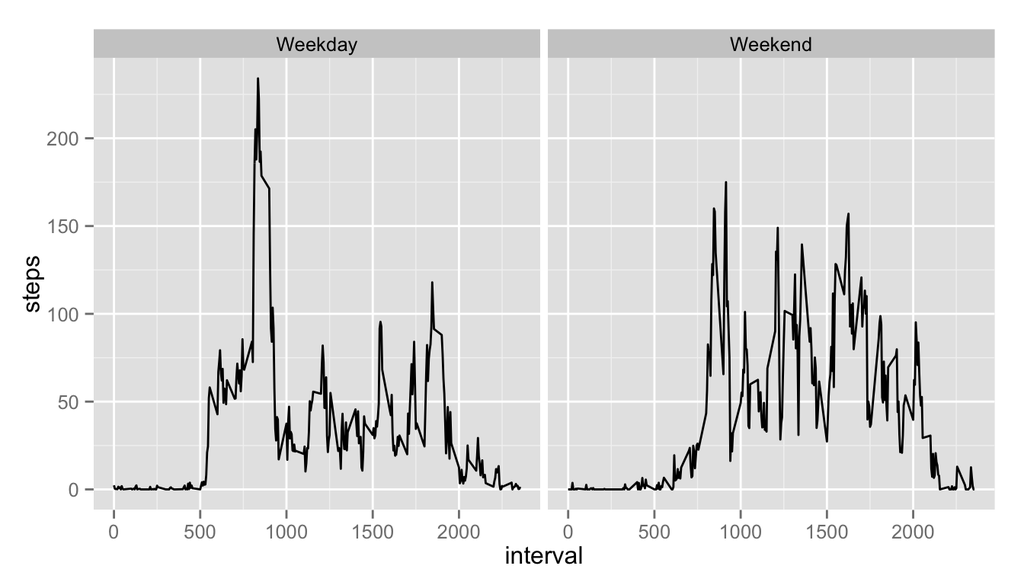

```r
library(ggplot2)
qplot(interval,steps,facets=.~weekday,data = df, stat = 'summary',fun.y = 'mean',geom='line',na.rm=TRUE)
```